# Environmental Performance Indexes

February 4th, 2017

## Environmental Performance Indexes

It becomes every day more and more inportant to highlight the world environmental status and human activities impact on sorrounding nature by collecting a pool of performance indicators named as Environmental Performance Indicators (EPI)

Furthermore, visualizing such EPI's in an interactive world map, providing a summary by regions and highlighting best and worst EPI at country level help a lot in having the global picture from the geographical perspective

That is the basic purpose of my proposed Shiny application

Let us spend some words about the available data and its source first

## Dataset available

The **rworldmap** R package provides a dataframe named as *CountryExData* reporting 2008 EPI data made available by

http://epi.yale.edu/

```
##   ISO3V10 Country Population2005 ECOSYSTEM BIODIVERSITY
## 1     AGO  Angola        15941.4      70.1         58.9
## 2     ALB Albania         3129.7      78.6          4.0
```

More specifically, the collected data is one of the results of the project lead by the Yale Center for Environmental Law & Policy (YCELP) and Yale Data-Driven Environmental Solutions Group at Yale University (Data-Driven Yale), the Center for International Earth Science Information Network (CIESIN) at Columbia University, in collaboration with the Samuel Family Foundation, McCall MacBain Foundation, and the World Economic Forum

## How my Shiny application works

There are three inputs that can be selected by the end users:

1. the Environmental Performance Index (EPI)
2. the regions classification type, determining the way countries are grouped in regions
3. the selection of a top-10 or a bottom-10 countries view

Three outputs are determined by above inputs selection:

1. the interactive map showing with gradient color scales the EPI values at country level
2. the table showing EPI values at region level, computed as average of the region member countries EPI's
3. the top-10/bottom-10 countries table as based on selected EPI metric

## Shiny Application

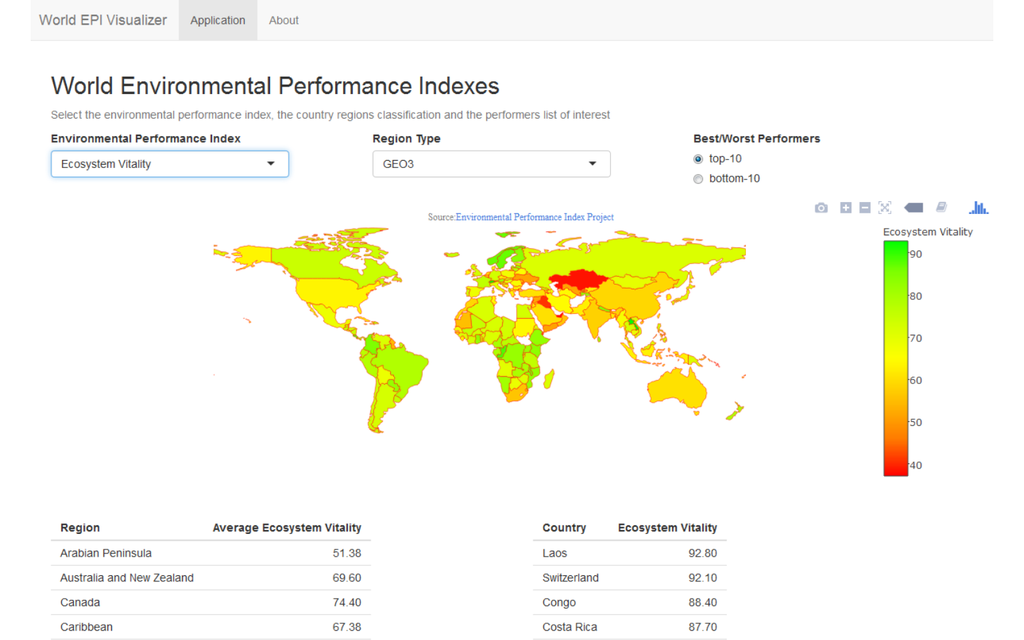